# Hay

Dr. Emily Burchfield

## Bright spots analysis

### Full panel overview

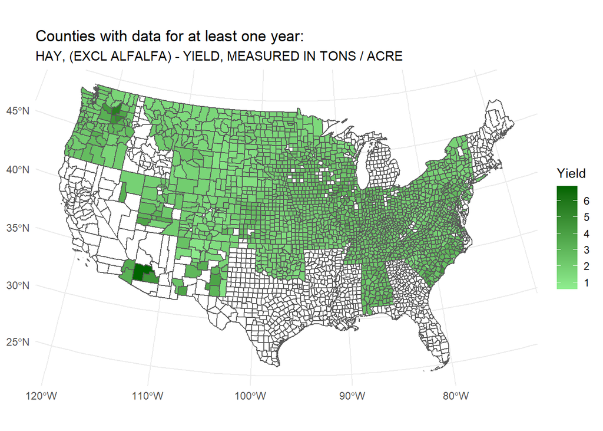

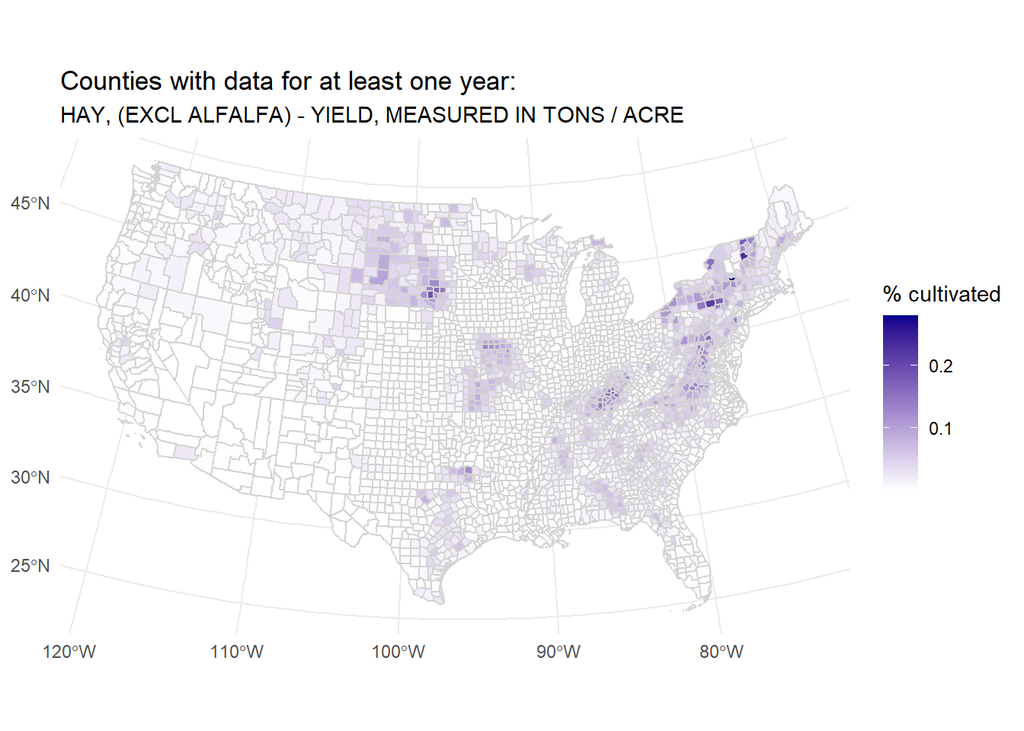

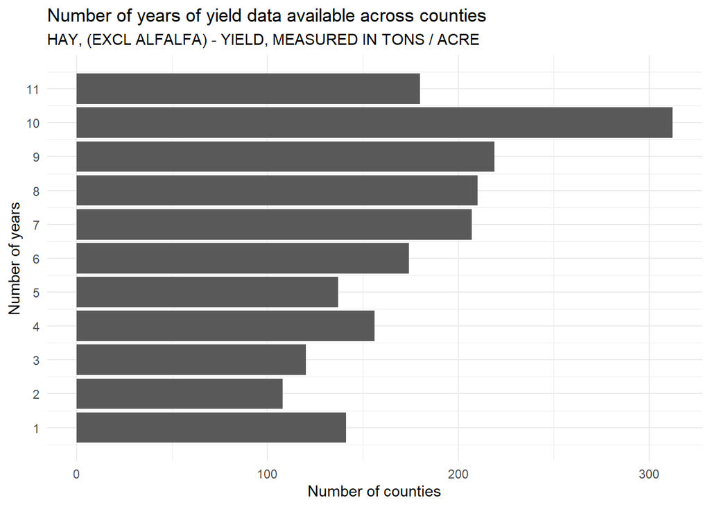

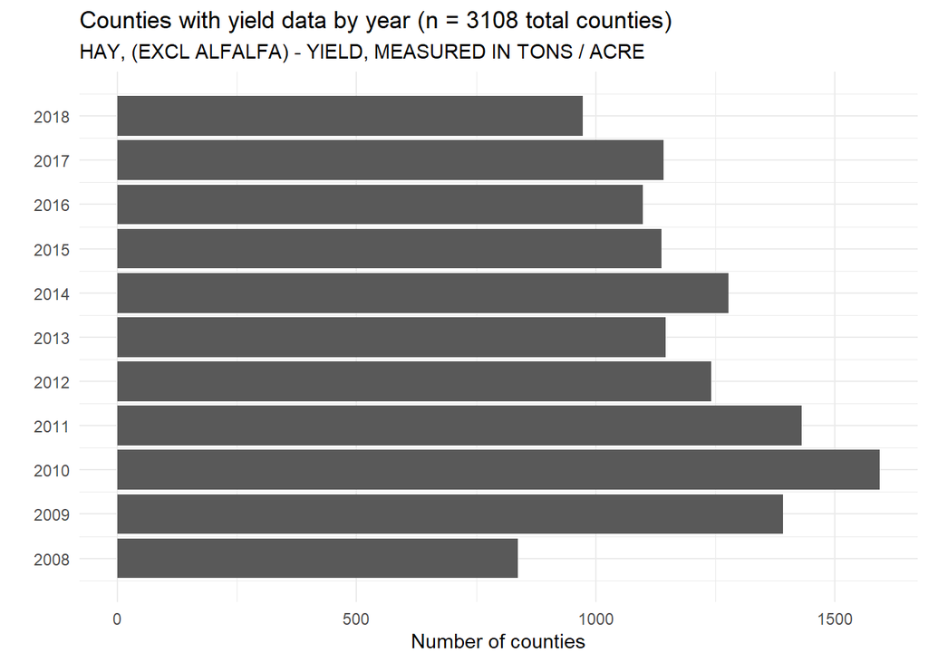

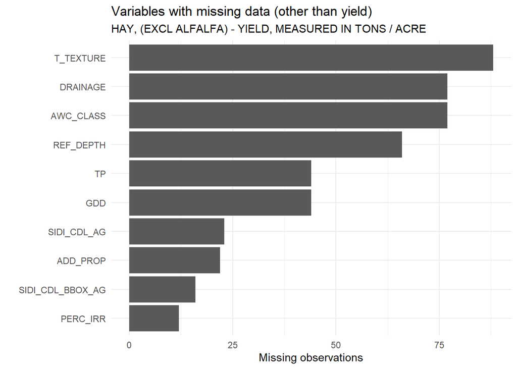

Notes on missing data:

- PRISM data is missing for the following counties due to a data corruption issue in the original PRISM data: `51600, 51610, 51678, 51685`
- `SIDI_CDL*_AG` columns are missing data in a few counties; likely due to the mask.

### Final panel overview

For the final panels, I have dropped rows with any missing data, eliminated FRRs with fewer than 10 counties, and selected only key variables. See `BS_sensitivity_testing.html` for an overview of the variable selection process.

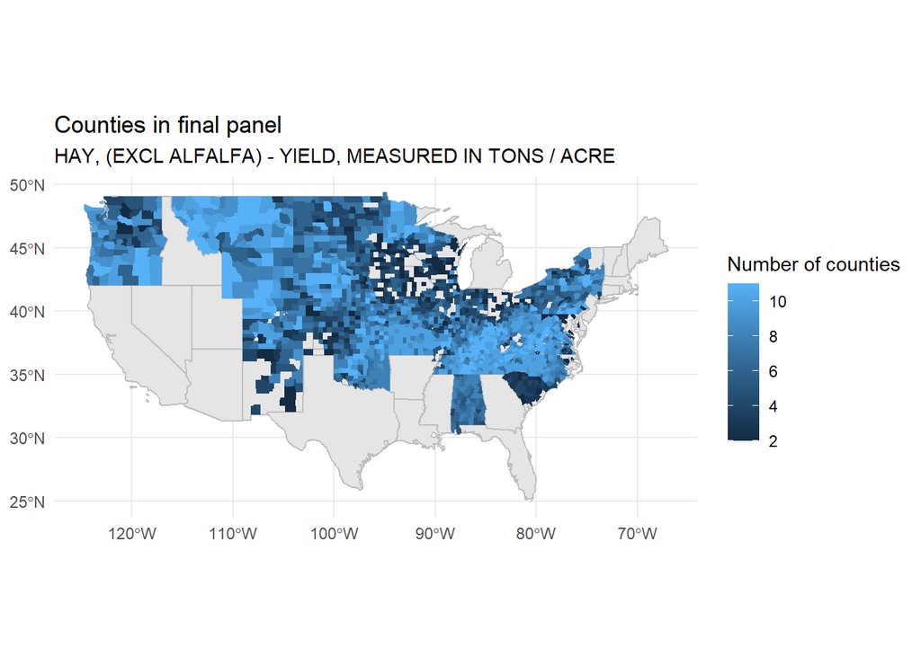

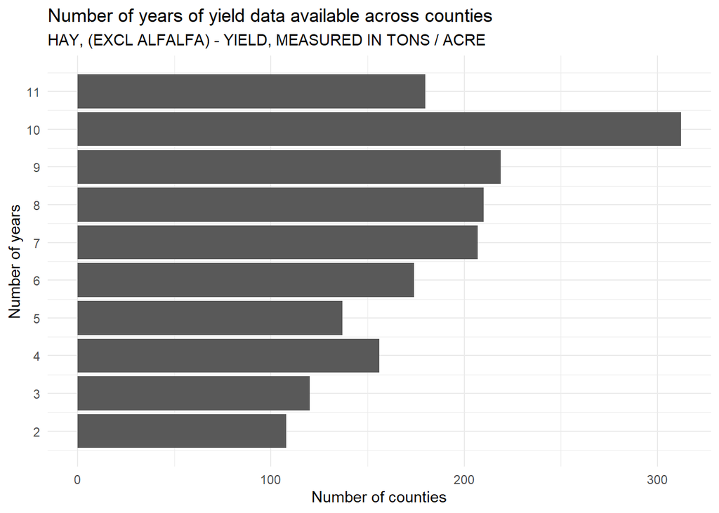

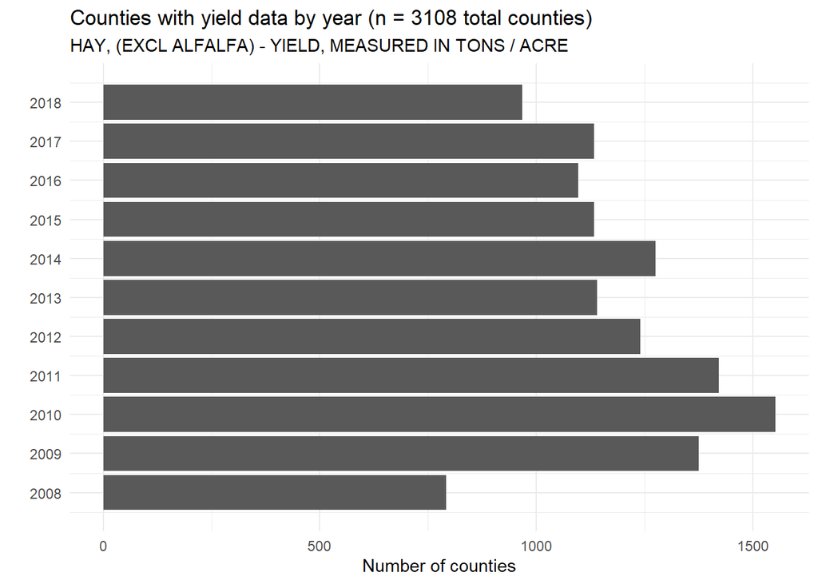

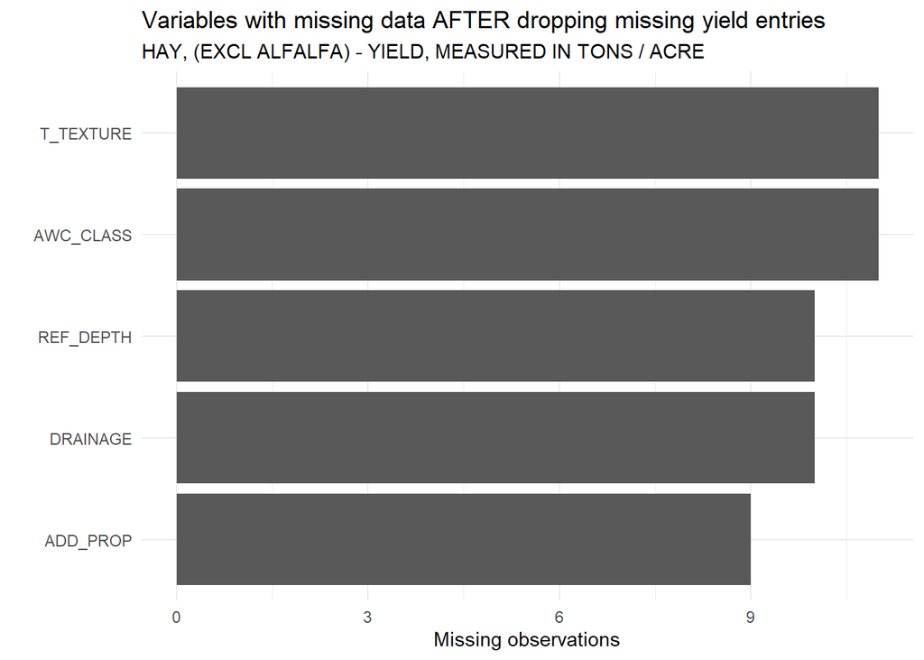

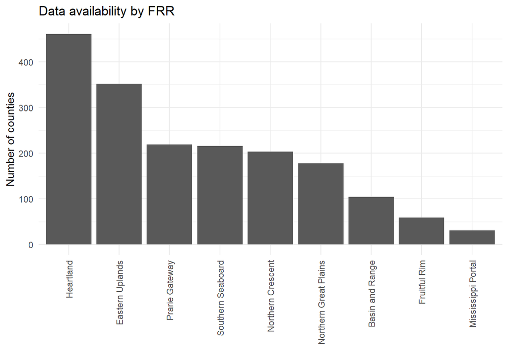

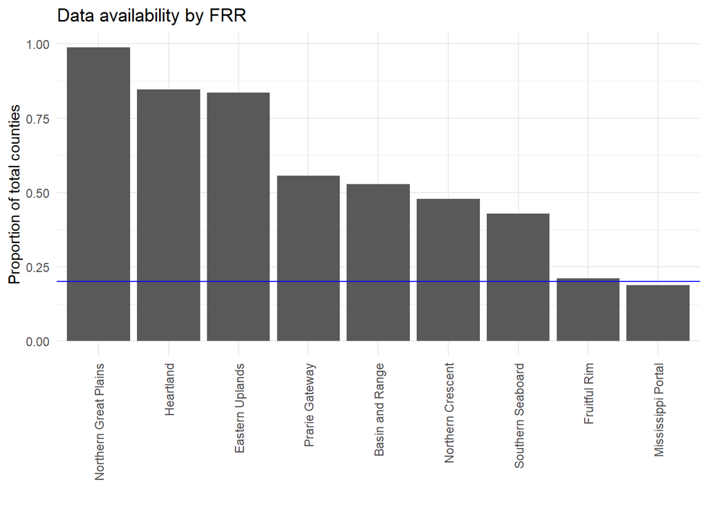

```
## [1] "Excluded FRRs are: "
```

```
## factor(0)
## 9 Levels: Basin and Range Eastern Uplands Fruitful Rim Heartland Mississippi Portal Northern Crescent ... Southern Seaboard
```

| FRR_ID | FRR_NAME | COUNTY_AV | COUNTY_TOTAL | PERC_AV |
| --- | --- | --- | --- | --- |
| 1 | Heartland | 461 | 544 | 0.8474265 |
| 2 | Northern Crescent | 203 | 424 | 0.4787736 |
| 3 | Northern Great Plains | 178 | 180 | 0.9888889 |
| 4 | Prarie Gateway | 219 | 394 | 0.5558376 |
| 5 | Eastern Uplands | 352 | 421 | 0.8361045 |
| 6 | Southern Seaboard | 216 | 503 | 0.4294235 |
| 7 | Fruitful Rim | 59 | 280 | 0.2107143 |
| 8 | Basin and Range | 104 | 197 | 0.5279188 |
| 9 | Mississippi Portal | 31 | 165 | 0.1878788 |

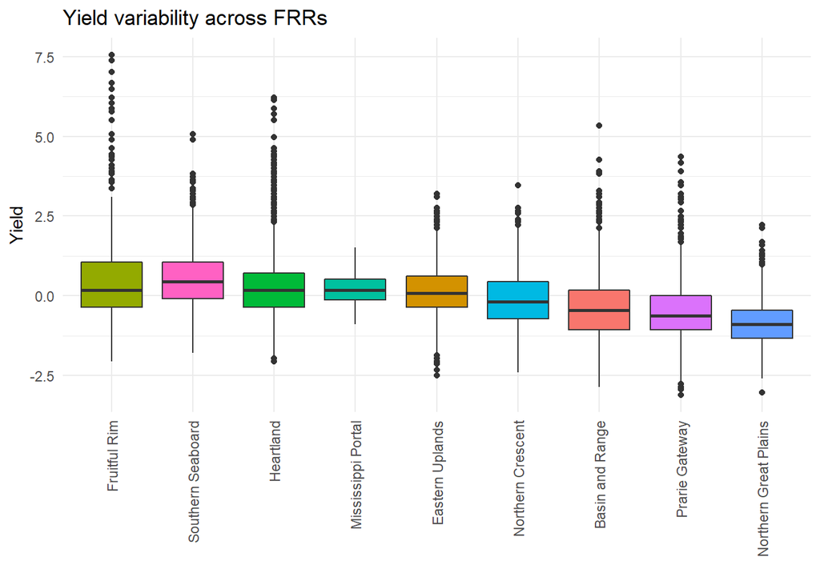

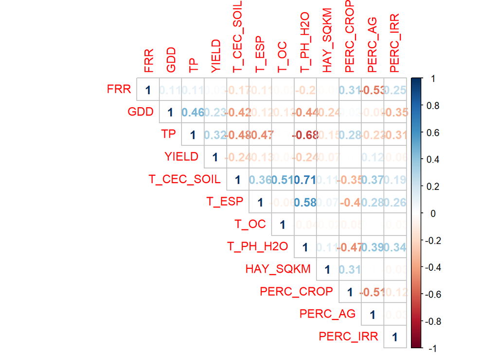

Here are the variables that still have a correlation above `0.5` (or below `-0.5`):

Variable pairs with high correlation

| Var1 | Var2 | Freq |
| --- | --- | --- |
| T_PH_H2O | T_CEC_SOIL | 0.71 |
| T_CEC_SOIL | T_PH_H2O | 0.71 |
| T_PH_H2O | TP | -0.68 |
| TP | T_PH_H2O | -0.68 |
| T_PH_H2O | T_ESP | 0.58 |
| T_ESP | T_PH_H2O | 0.58 |
| PERC_AG | FRR | -0.53 |
| FRR | PERC_AG | -0.53 |
| T_OC | T_CEC_SOIL | 0.51 |
| T_CEC_SOIL | T_OC | 0.51 |
| PERC_AG | PERC_CROP | -0.51 |
| PERC_CROP | PERC_AG | -0.51 |

And for reference, here is the adjacency structure used in the models:

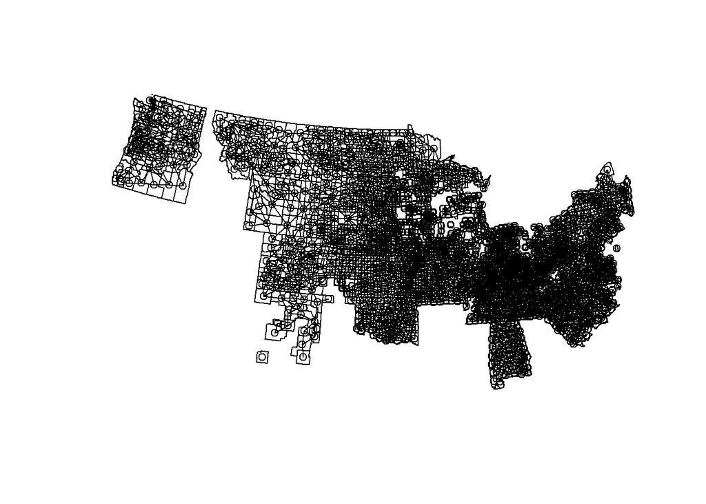

### Model specification

```r
  out <- prep_data(crop)
  null <- out[[1]]
  county_sub <- out[[2]]
  hadj <- build_adj_matrix(county_sub)

  null <- null %>% mutate_at(c("GDD", "TP"), ~inla.group(., n = 20, method = "quantile"))
  u <- sd(null$YIELD, na.rm = T)

  apar <- 0.5
  lmod <- lm(YIELD ~ GDD + TP  + T_CEC_SOIL + T_OC + T_PH_H2O + T_ESP +
               PERC_IRR +
               factor(YEAR), data=  null)
  bpar <- apar*var(residuals(lmod))
  lgprior <- list(prec = list(prior = "loggamma", param = c(apar, bpar)))

  formula <- YIELD ~ 1 +
    f(ID, model="bym2",
      graph=hadj,
      scale.model=TRUE,
      constr = TRUE) +
    f(FRR, model = "iid", hyper = lgprior) +
    f(GDD, model = "rw2",
      scale.model = T,
      hyper = list(theta = list(prior = "pc.prec",
                                param = c(u, 0.01)))) +
    f(TP, model = "rw2",
      scale.model = T,
      hyper = list(theta = list(prior = "pc.prec",
                                param = c(u, 0.01)))) +
    PERC_IRR +
    T_CEC_SOIL + T_OC + T_PH_H2O + T_ESP +
    factor(YEAR)

  mf <- inla(formula, data=null, family="gaussian",
             control.predictor = list(compute=T),
             control.compute = list(dic=T, cpo=T))
  df <- model_diagnostics(mf, null)
```

### Model results

Remember that variables have been *scaled* prior to running the analysis.

```
##
## Call:
##    c("inla(formula = formula, family = \"gaussian\", data = null, control.compute = list(dic = T, ", " cpo = T),
##    control.predictor = list(compute = T))")
## Time used:
##     Pre = 14.2, Running = 41.8, Post = 1.02, Total = 56.9
## Fixed effects:
##                    mean    sd 0.025quant 0.5quant 0.975quant   mode kld
## (Intercept)      -0.228 0.129     -0.484   -0.228      0.027 -0.229   0
## PERC_IRR          0.049 0.014      0.021    0.049      0.076  0.049   0
## T_CEC_SOIL       -0.067 0.039     -0.144   -0.067      0.011 -0.067   0
## T_OC              0.025 0.028     -0.030    0.025      0.080  0.025   0
## T_PH_H2O          0.272 0.047      0.179    0.272      0.365  0.272   0
## T_ESP             0.022 0.019     -0.016    0.022      0.060  0.022   0
## factor(YEAR)2009  0.217 0.028      0.162    0.217      0.273  0.217   0
## factor(YEAR)2010  0.209 0.029      0.151    0.209      0.266  0.209   0
## factor(YEAR)2011  0.164 0.030      0.106    0.164      0.223  0.164   0
## factor(YEAR)2012  0.130 0.035      0.062    0.130      0.198  0.130   0
## factor(YEAR)2013  0.239 0.030      0.181    0.239      0.298  0.239   0
## factor(YEAR)2014  0.331 0.029      0.274    0.331      0.389  0.331   0
## factor(YEAR)2015  0.469 0.033      0.405    0.469      0.533  0.469   0
## factor(YEAR)2016  0.540 0.034      0.473    0.540      0.608  0.540   0
## factor(YEAR)2017  0.382 0.032      0.318    0.382      0.445  0.382   0
## factor(YEAR)2018  0.317 0.033      0.252    0.317      0.381  0.317   0
##
## Random effects:
##   Name     Model
##     ID BYM2 model
##    FRR IID model
##    GDD RW2 model
##    TP RW2 model
##
## Model hyperparameters:
##                                            mean      sd 0.025quant 0.5quant 0.975quant  mode
## Precision for the Gaussian observations   2.635   0.036      2.561    2.636       2.70  2.64
## Precision for ID                          1.386   0.125      1.111    1.402       1.58  1.48
## Phi for ID                                0.998   0.002      0.992    0.999       1.00  1.00
## Precision for FRR                         8.138   4.001      2.696    7.389      18.05  5.93
## Precision for GDD                       157.082 162.247     24.098  108.947     581.40 57.91
## Precision for TP                         71.368  71.830      8.895   50.363     262.29 23.62
##
## Expected number of effective parameters(stdev): 1371.45(13.30)
## Number of equivalent replicates : 9.57
##
## Deviance Information Criterion (DIC) ...............: 25916.44
## Deviance Information Criterion (DIC, saturated) ....: 14541.30
## Effective number of parameters .....................: 1373.07
##
## Marginal log-Likelihood:  -13375.38
## CPO and PIT are computed
##
## Posterior marginals for the linear predictor and
##  the fitted values are computed
```

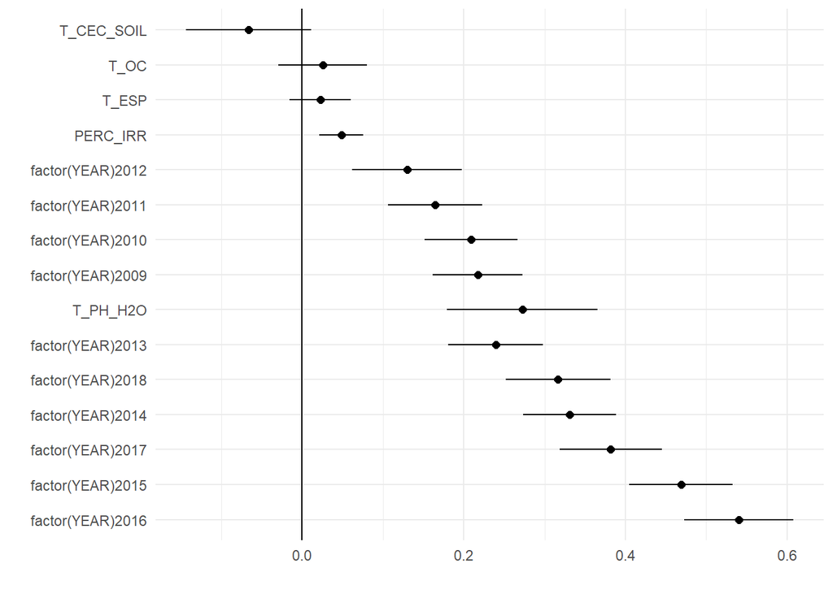

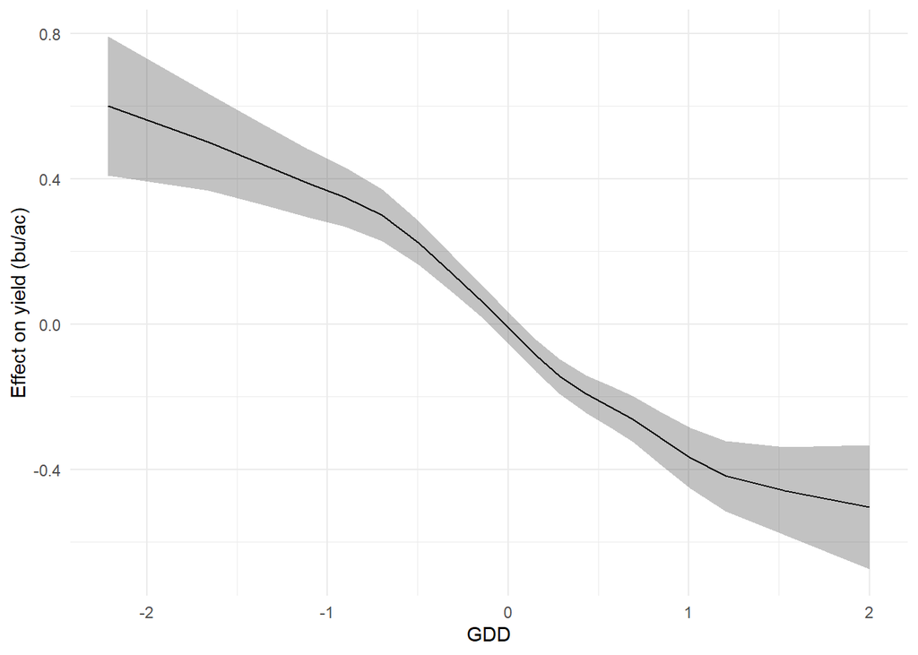

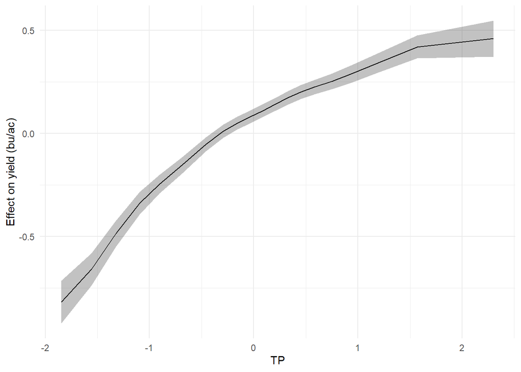

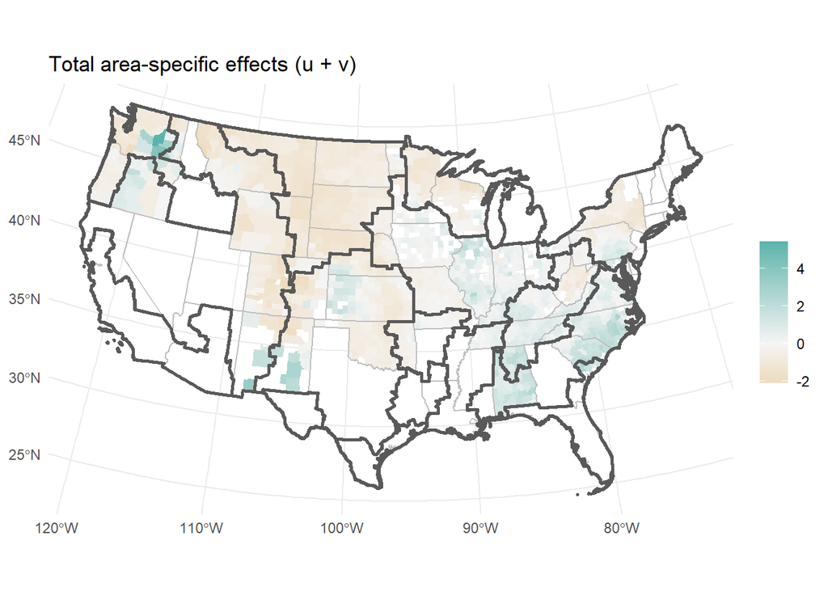

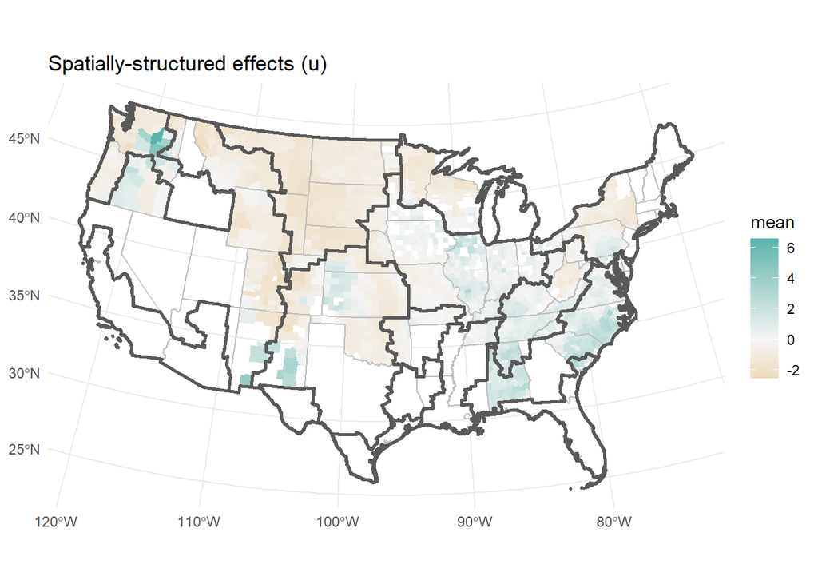

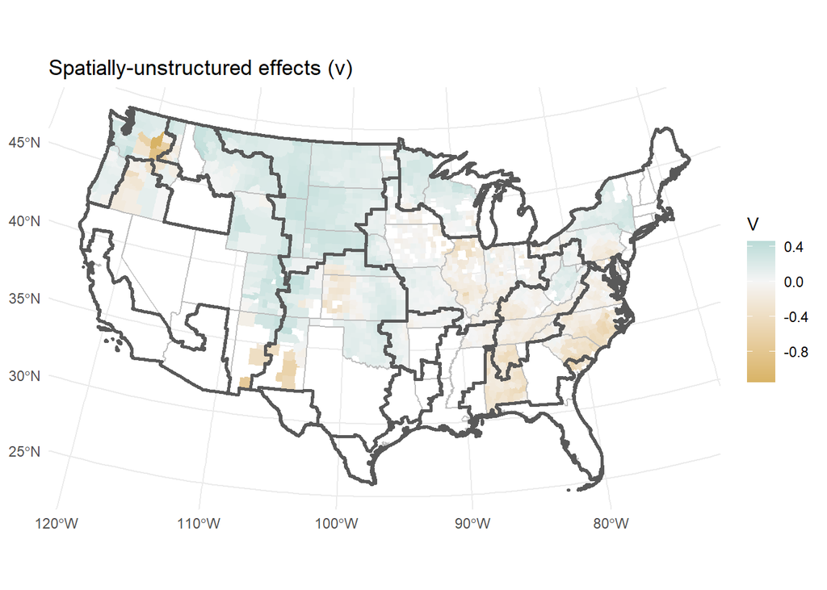

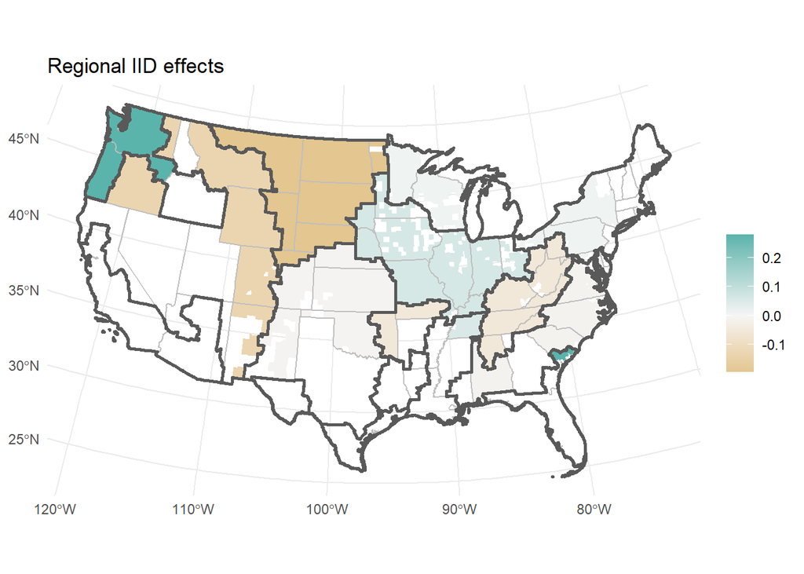

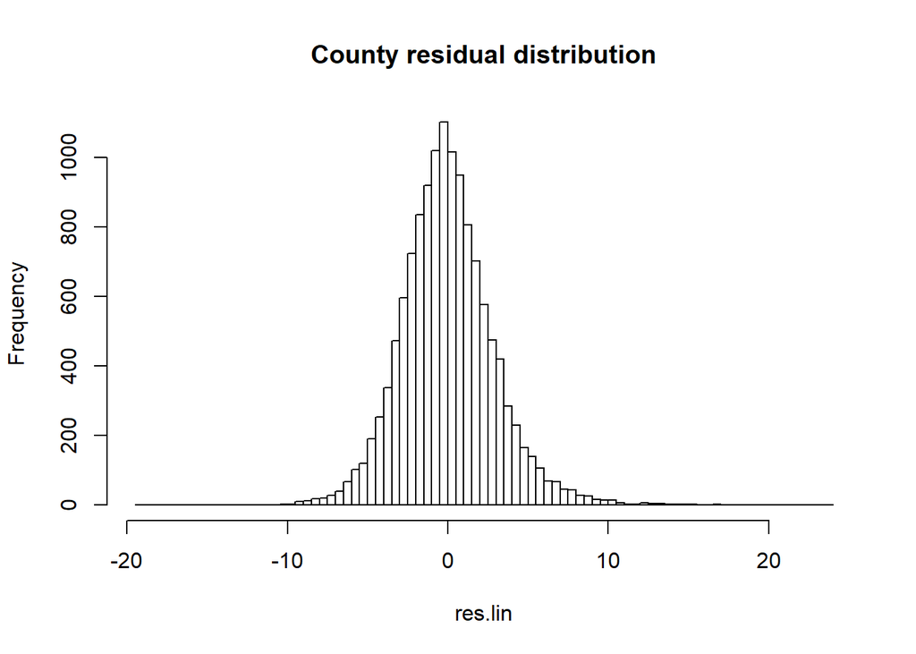

### Model diagnostics

How about general model diagnostics:

```r
modd$DIC
```

```
## [1] 25916.43
```

```r
modd$CPO
```

```
## [1] -13104.32
```

```r
modd$MSE
```

```
## [1] 0.3400718
```

```r
modd$R2
```

```
## [1] 0.5802684
```

The probability integral transform (PIT) is another leave-one-out-cross-validation check that evaluates the predictive performance of the model where a Uniform distribution of PIT means the predictive distribution matches well with the data.

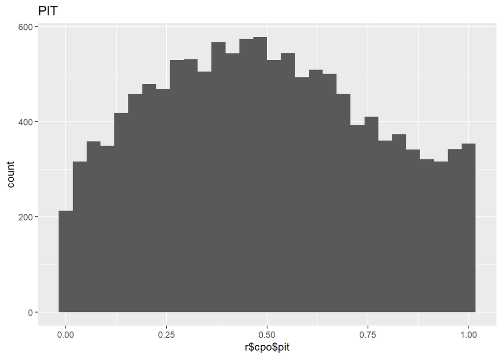

The second PPC provides a histogram of the posterior predictive p-value which estimates the probability of predicting a value more extreme than the observed value, where values near 0 and 1 indicate that the model does not adequately account for the tails of the observed distribution.

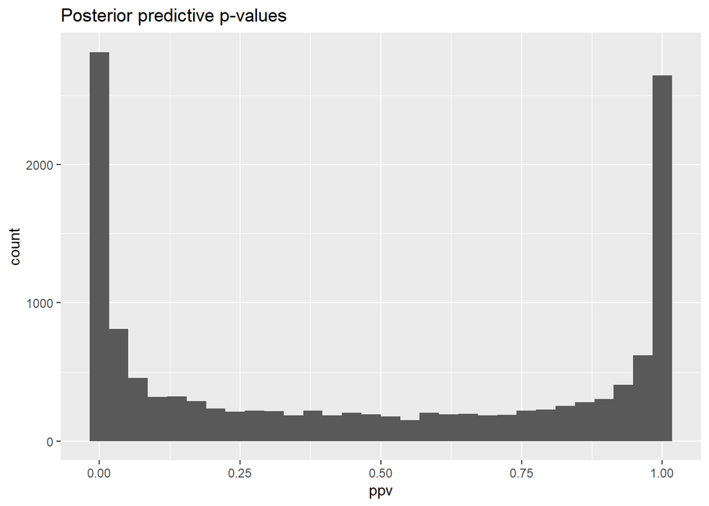

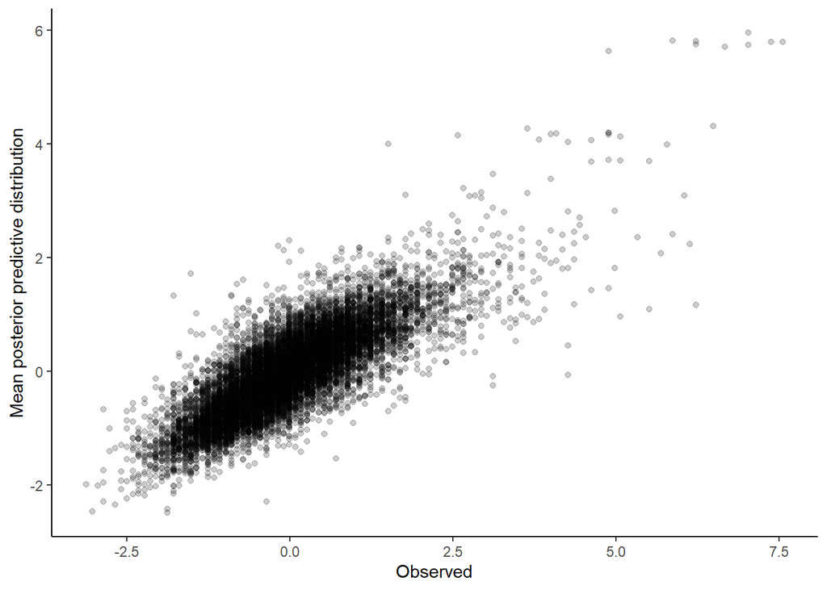

### FRR bright spots

#### First with “county effects” as u + v

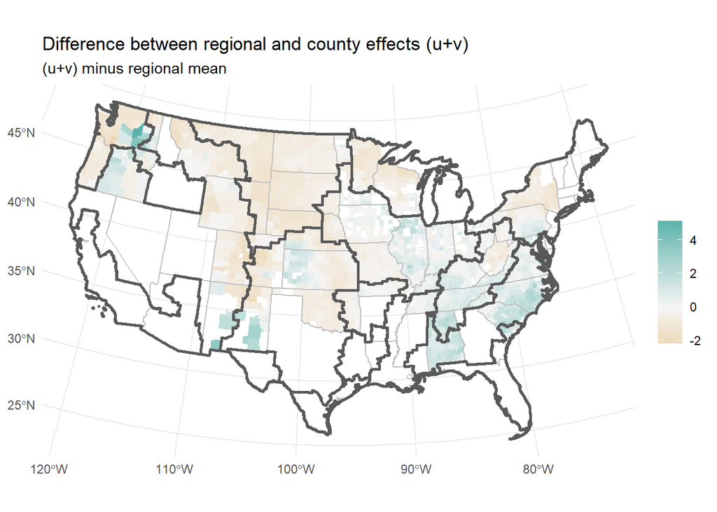

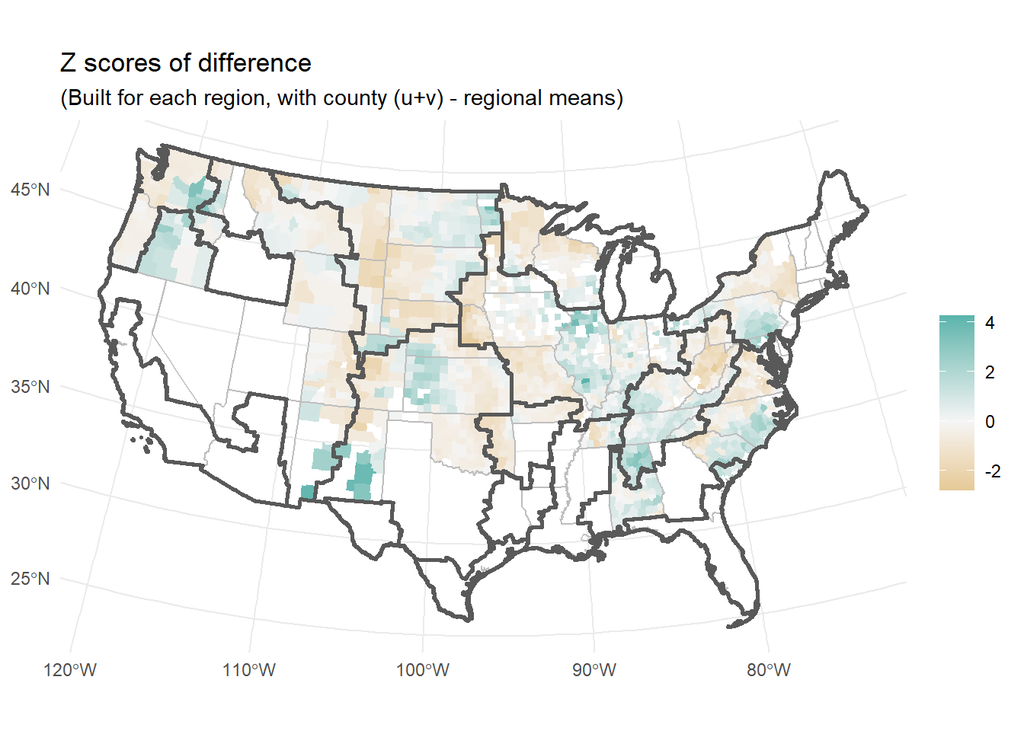

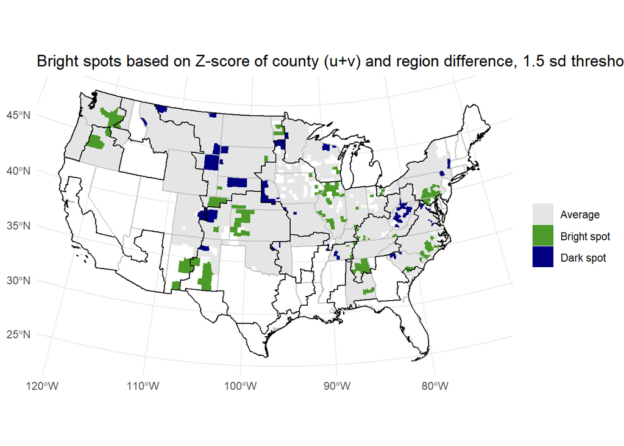

#### Now with “county effects” as v only

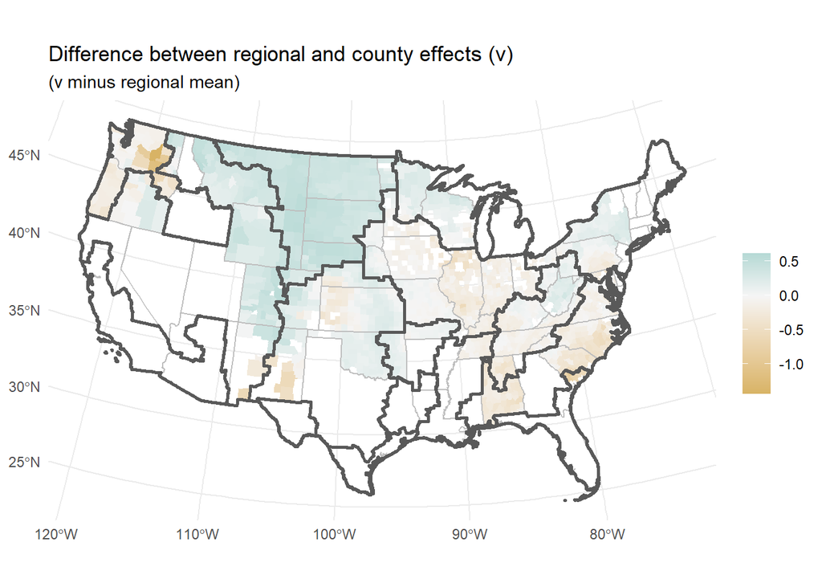

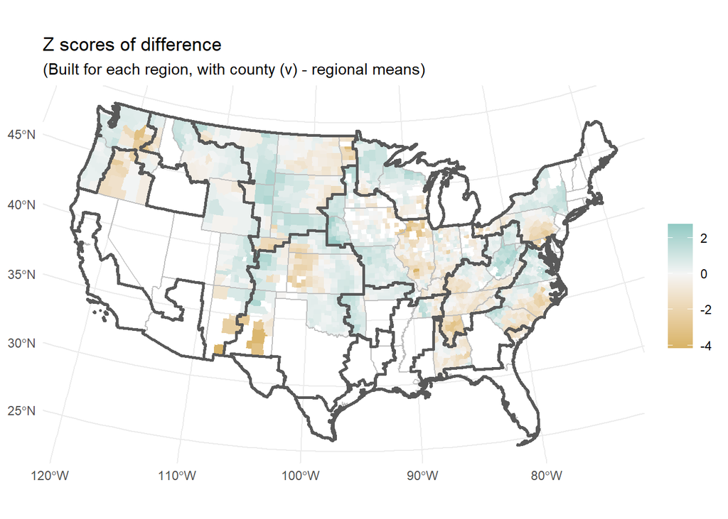

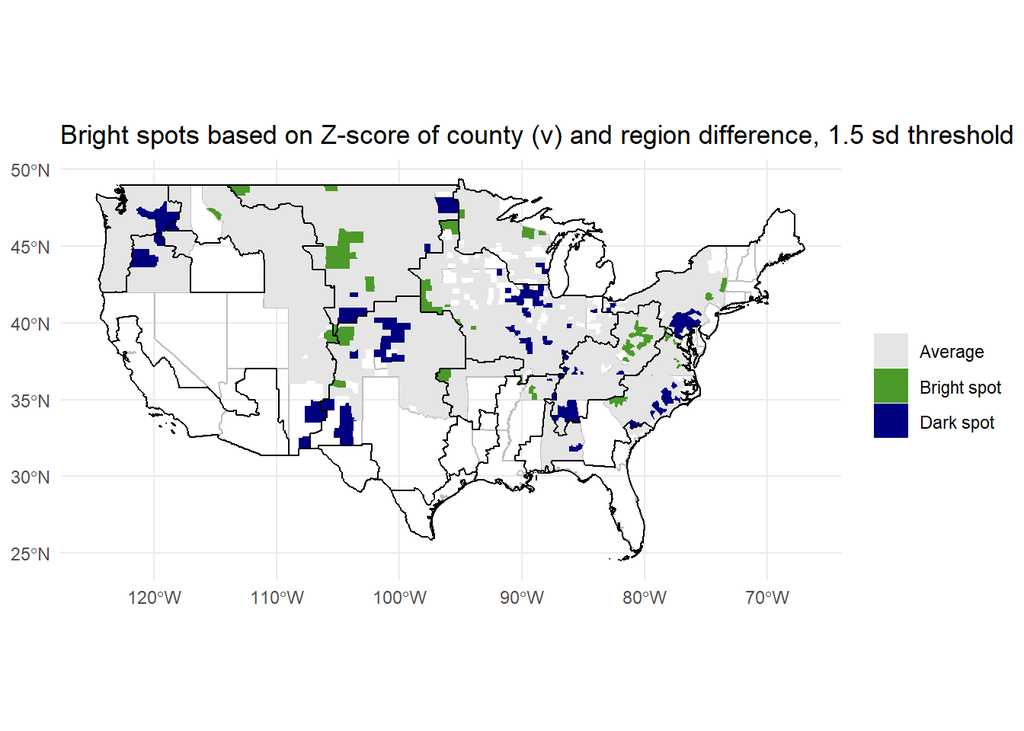